# Activity: Street or Road?

DEEKSHITH REDDY BHOOMIREDDY

## Load in the data

```r
#load in the data here
# we will only be using the "street-addresses.csv" file from the text
download.file(url = "https://mdbeckman.github.io/dcSupplement/data/CMS_ProvidersSimple.rds",
              destfile = "Your-Name-For-The-File.rds")
#load in the data here
# we will only be using the "street-addresses.csv" file from the text
download.file(url = "https://mdbeckman.github.io/dcSupplement/data/CMS_ProvidersSimple.rds",
              destfile = "Your-Name-For-The-File.rds")
DataTable <- readRDS("Your-Name-For-The-File.rds")
```

## Recreate Solved Example using `sample(50)`

```r
Addresses <- read_csv("https://mdbeckman.github.io/dcSupplement/data/street-addresses.csv")
```

## Recreate Soved Example using the entire `Address` data set

```r
Matches <-
  Sample %>%
  filter(grepl(pattern, Address))
```

[output not shown]

#### Additional Question: How many addresses are a PO BOX (including NCSU BOX)?

```r
Matches
```

[output not shown]

My answer here…… 10552 addresses are a PO BOX (including NCSU BOX)

## Back to the Streets: Your Turn

My answer here…….

- pattern <- “(ST|RD|ROAD)”: This line stores “(ST|RD|ROAD)” in the variable ‘pattern’, but this will later be used to match and filter out the street endings with “ST”, “RD”, “ROAD”.
- LeftOvers <-: It is a variable called “LeftOvers” in which the code below this is stored.
- Addresses %>% : This initiates the “Addresses” data set and passes the output to the filter function in the next line using the pipe operator
- filter( !grepl(pattern, address),: Filters out and removes the address that matches the data stored in the pattern variable or simply it filter out and removes the street endings with “ST”, “RD”, “ROAD”.
- !grepl(“\sAPT|UNIT\s[\d]+$”, address),: This filters out and removes the addresses ending with “APT” or “UNIT” and followed by digits
- !grepl(” BOX “, address): Filters out and removes address that contain this-” BOX “.

My answer here…….

- pattern <- “(RD|LANE|AVE|DR|CT)”: This line stores “(RD|LANE|AVE|DR|CT)” in the variable ‘pattern’, but this will later be used to match and filter out the street endings with “RD”, “LANE”, “AVE”, “DR”, “CT”.
- AddressTypes <-: It is a variable called “AddressTypes” in which the code below this is stored.
- Addresses %>% : This initiates the “Addresses” data set and passes the output to the filter function in the next line as an input using the pipe operator
- filter(grepl(pattern, address),: Filters and stores the address that matches the data stored in the pattern variable or simply it filter and stores the street endings with “RD”, “LANE”, “AVE”, “DR”, “CT”.
- !grepl(“PO”, address),: Filters out and removes address that contain this- “PO”.
- !grepl(“NCS”, address)) %>%: Filters out and removes address that contain this- “PO”. Moreover, the pipe operator passes this output (from the whole filter function) as an input to the mutate function in the next line.
- mutate(Includes = str_extract(address, pattern)) %>%: Creates a new column named ‘Includes’ by extracting the first complete matching street ending pattern form each of the stored address. Moreover, the pipe operator passes this output (from the mutate function) as an input to the group_by function in the next line.
- group_by(Includes) %>%: Groups the data according to the ‘Includes’ column. The pipe operator passes this output (from the group_by function) as an input to the summarise function in the next line.
- summarise(count = n()): Summarises the data by counting the number of occurences of each of the type in ‘Includes’ variable.

#### Additional Question 1: Present your result from part 2 by providing a table in descending order of popularity for the street name endings you found

| Includes | count |
| --- | --- |
| DR | 869 |
| RD | 820 |
| AVE | 291 |
| CT | 237 |
| LANE | 139 |

#### Additional Question 2: Present your result by using ggplot to a bar chart in descending order of popularity for the street name endings you found previously.

Note: make sure your order street names according to popularity, not alphabetically.

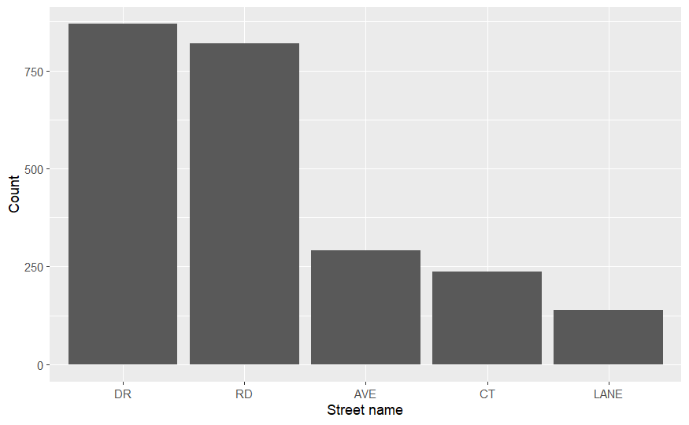

#### Additional Question 3: Comment on any patterns you see

My answer here……. Based on the following graph we can observe that streets like “DR” and “RD” are more common than streets like “LANE” and “CT”. Meaning that street types like “DR” and “RD” are the most common in the area from which this ‘street addresses’ data set was collected.